# Risk Factor Analysis

## Outcome Variable

**Outcome Variable:** y_rate_wtkg

## Predictor Variables

**Intervention Variable:** predfeed3

**Adjustment Set:**

- arm
- sex
- month
- brthmon
- W_mage
- meducyrs
- feducyrs
- hhwealth_quart
- hfoodsec
- W_mhtcm
- W_mwtkg
- W_mbmi
- vagbrth
- W_gagebrth
- W_birthwt
- W_birthlen
- W_nrooms
- W_nchldlt5
- W_parity
- impfloor
- impsan
- safeh20
- delta_W_mage
- delta_meducyrs
- delta_feducyrs
- delta_hhwealth_quart
- delta_hfoodsec
- delta_W_mhtcm
- delta_W_mwtkg
- delta_W_mbmi
- delta_vagbrth
- delta_W_gagebrth
- delta_W_birthwt
- delta_W_birthlen
- delta_W_nrooms
- delta_W_nchldlt5
- delta_W_parity
- delta_impfloor
- delta_impsan
- delta_safeh20

## Stratifying Variables

The analysis was stratified on these variable(s):

- agecat
- studyid
- country

## Data Summary

| agecat | studyid | country | predfeed3 | n_cell | n | outcome_variable |
| --- | --- | --- | --- | --- | --- | --- |
| 0-3 months | ki0047075b-MAL-ED | BANGLADESH | 1 | 195 | 239 | y_rate_wtkg |
| 0-3 months | ki0047075b-MAL-ED | BANGLADESH | 0 | 44 | 239 | y_rate_wtkg |
| 0-3 months | ki0047075b-MAL-ED | BRAZIL | 1 | 96 | 195 | y_rate_wtkg |
| 0-3 months | ki0047075b-MAL-ED | BRAZIL | 0 | 99 | 195 | y_rate_wtkg |
| 0-3 months | ki0047075b-MAL-ED | INDIA | 1 | 151 | 213 | y_rate_wtkg |
| 0-3 months | ki0047075b-MAL-ED | INDIA | 0 | 62 | 213 | y_rate_wtkg |
| 0-3 months | ki0047075b-MAL-ED | NEPAL | 1 | 111 | 224 | y_rate_wtkg |
| 0-3 months | ki0047075b-MAL-ED | NEPAL | 0 | 113 | 224 | y_rate_wtkg |
| 0-3 months | ki0047075b-MAL-ED | PERU | 1 | 181 | 279 | y_rate_wtkg |
| 0-3 months | ki0047075b-MAL-ED | PERU | 0 | 98 | 279 | y_rate_wtkg |
| 0-3 months | ki0047075b-MAL-ED | SOUTH AFRICA | 1 | 70 | 261 | y_rate_wtkg |
| 0-3 months | ki0047075b-MAL-ED | SOUTH AFRICA | 0 | 191 | 261 | y_rate_wtkg |
| 0-3 months | ki0047075b-MAL-ED | TANZANIA, UNITED REPUBLIC OF | 1 | 59 | 205 | y_rate_wtkg |
| 0-3 months | ki0047075b-MAL-ED | TANZANIA, UNITED REPUBLIC OF | 0 | 146 | 205 | y_rate_wtkg |
| 0-3 months | ki1000109-EE | PAKISTAN | 1 | 32 | 32 | y_rate_wtkg |
| 0-3 months | ki1000109-EE | PAKISTAN | 0 | 0 | 32 | y_rate_wtkg |
| 0-3 months | ki1113344-GMS-Nepal | NEPAL | 1 | 378 | 455 | y_rate_wtkg |
| 0-3 months | ki1113344-GMS-Nepal | NEPAL | 0 | 77 | 455 | y_rate_wtkg |
| 0-3 months | kiGH5241-JiVitA-3 | BANGLADESH | 1 | 10916 | 12098 | y_rate_wtkg |
| 0-3 months | kiGH5241-JiVitA-3 | BANGLADESH | 0 | 1182 | 12098 | y_rate_wtkg |
| 0-3 months | kiGH5241-JiVitA-4 | BANGLADESH | 1 | 141 | 157 | y_rate_wtkg |
| 0-3 months | kiGH5241-JiVitA-4 | BANGLADESH | 0 | 16 | 157 | y_rate_wtkg |
| 3-6 months | ki0047075b-MAL-ED | BANGLADESH | 1 | 184 | 226 | y_rate_wtkg |
| 3-6 months | ki0047075b-MAL-ED | BANGLADESH | 0 | 42 | 226 | y_rate_wtkg |
| 3-6 months | ki0047075b-MAL-ED | BRAZIL | 1 | 93 | 186 | y_rate_wtkg |
| 3-6 months | ki0047075b-MAL-ED | BRAZIL | 0 | 93 | 186 | y_rate_wtkg |
| 3-6 months | ki0047075b-MAL-ED | INDIA | 1 | 146 | 206 | y_rate_wtkg |
| 3-6 months | ki0047075b-MAL-ED | INDIA | 0 | 60 | 206 | y_rate_wtkg |
| 3-6 months | ki0047075b-MAL-ED | NEPAL | 1 | 112 | 226 | y_rate_wtkg |
| 3-6 months | ki0047075b-MAL-ED | NEPAL | 0 | 114 | 226 | y_rate_wtkg |

[output cut: 130 more lines]

The following strata were considered:

- agecat: 0-3 months, studyid: ki0047075b-MAL-ED, country: BANGLADESH
- agecat: 0-3 months, studyid: ki0047075b-MAL-ED, country: BRAZIL
- agecat: 0-3 months, studyid: ki0047075b-MAL-ED, country: INDIA
- agecat: 0-3 months, studyid: ki0047075b-MAL-ED, country: NEPAL
- agecat: 0-3 months, studyid: ki0047075b-MAL-ED, country: PERU
- agecat: 0-3 months, studyid: ki0047075b-MAL-ED, country: SOUTH AFRICA
- agecat: 0-3 months, studyid: ki0047075b-MAL-ED, country: TANZANIA, UNITED REPUBLIC OF
- agecat: 0-3 months, studyid: ki1000109-EE, country: PAKISTAN
- agecat: 0-3 months, studyid: ki1113344-GMS-Nepal, country: NEPAL
- agecat: 0-3 months, studyid: kiGH5241-JiVitA-3, country: BANGLADESH
- agecat: 0-3 months, studyid: kiGH5241-JiVitA-4, country: BANGLADESH
- agecat: 12-15 months, studyid: ki0047075b-MAL-ED, country: BANGLADESH
- agecat: 12-15 months, studyid: ki0047075b-MAL-ED, country: BRAZIL
- agecat: 12-15 months, studyid: ki0047075b-MAL-ED, country: INDIA
- agecat: 12-15 months, studyid: ki0047075b-MAL-ED, country: NEPAL
- agecat: 12-15 months, studyid: ki0047075b-MAL-ED, country: PERU
- agecat: 12-15 months, studyid: ki0047075b-MAL-ED, country: SOUTH AFRICA
- agecat: 12-15 months, studyid: ki0047075b-MAL-ED, country: TANZANIA, UNITED REPUBLIC OF
- agecat: 12-15 months, studyid: ki1000109-EE, country: PAKISTAN
- agecat: 12-15 months, studyid: ki1113344-GMS-Nepal, country: NEPAL
- agecat: 12-15 months, studyid: kiGH5241-JiVitA-4, country: BANGLADESH
- agecat: 15-18 months, studyid: ki0047075b-MAL-ED, country: BANGLADESH
- agecat: 15-18 months, studyid: ki0047075b-MAL-ED, country: BRAZIL
- agecat: 15-18 months, studyid: ki0047075b-MAL-ED, country: INDIA
- agecat: 15-18 months, studyid: ki0047075b-MAL-ED, country: NEPAL
- agecat: 15-18 months, studyid: ki0047075b-MAL-ED, country: PERU
- agecat: 15-18 months, studyid: ki0047075b-MAL-ED, country: SOUTH AFRICA
- agecat: 15-18 months, studyid: ki0047075b-MAL-ED, country: TANZANIA, UNITED REPUBLIC OF
- agecat: 15-18 months, studyid: ki1000109-EE, country: PAKISTAN
- agecat: 15-18 months, studyid: ki1113344-GMS-Nepal, country: NEPAL
- agecat: 15-18 months, studyid: kiGH5241-JiVitA-4, country: BANGLADESH
- agecat: 18-21 months, studyid: ki0047075b-MAL-ED, country: BANGLADESH
- agecat: 18-21 months, studyid: ki0047075b-MAL-ED, country: BRAZIL
- agecat: 18-21 months, studyid: ki0047075b-MAL-ED, country: INDIA
- agecat: 18-21 months, studyid: ki0047075b-MAL-ED, country: NEPAL
- agecat: 18-21 months, studyid: ki0047075b-MAL-ED, country: PERU
- agecat: 18-21 months, studyid: ki0047075b-MAL-ED, country: SOUTH AFRICA
- agecat: 18-21 months, studyid: ki0047075b-MAL-ED, country: TANZANIA, UNITED REPUBLIC OF
- agecat: 18-21 months, studyid: ki1000109-EE, country: PAKISTAN
- agecat: 18-21 months, studyid: ki1113344-GMS-Nepal, country: NEPAL
- agecat: 21-24 months, studyid: ki0047075b-MAL-ED, country: BANGLADESH
- agecat: 21-24 months, studyid: ki0047075b-MAL-ED, country: BRAZIL
- agecat: 21-24 months, studyid: ki0047075b-MAL-ED, country: INDIA
- agecat: 21-24 months, studyid: ki0047075b-MAL-ED, country: NEPAL
- agecat: 21-24 months, studyid: ki0047075b-MAL-ED, country: PERU
- agecat: 21-24 months, studyid: ki0047075b-MAL-ED, country: SOUTH AFRICA
- agecat: 21-24 months, studyid: ki0047075b-MAL-ED, country: TANZANIA, UNITED REPUBLIC OF
- agecat: 21-24 months, studyid: ki1000109-EE, country: PAKISTAN
- agecat: 21-24 months, studyid: ki1113344-GMS-Nepal, country: NEPAL
- agecat: 3-6 months, studyid: ki0047075b-MAL-ED, country: BANGLADESH
- agecat: 3-6 months, studyid: ki0047075b-MAL-ED, country: BRAZIL
- agecat: 3-6 months, studyid: ki0047075b-MAL-ED, country: INDIA
- agecat: 3-6 months, studyid: ki0047075b-MAL-ED, country: NEPAL
- agecat: 3-6 months, studyid: ki0047075b-MAL-ED, country: PERU
- agecat: 3-6 months, studyid: ki0047075b-MAL-ED, country: SOUTH AFRICA
- agecat: 3-6 months, studyid: ki0047075b-MAL-ED, country: TANZANIA, UNITED REPUBLIC OF
- agecat: 3-6 months, studyid: ki1000109-EE, country: PAKISTAN
- agecat: 3-6 months, studyid: ki1113344-GMS-Nepal, country: NEPAL
- agecat: 3-6 months, studyid: kiGH5241-JiVitA-3, country: BANGLADESH
- agecat: 3-6 months, studyid: kiGH5241-JiVitA-4, country: BANGLADESH
- agecat: 6-9 months, studyid: ki0047075b-MAL-ED, country: BANGLADESH
- agecat: 6-9 months, studyid: ki0047075b-MAL-ED, country: BRAZIL
- agecat: 6-9 months, studyid: ki0047075b-MAL-ED, country: INDIA
- agecat: 6-9 months, studyid: ki0047075b-MAL-ED, country: NEPAL
- agecat: 6-9 months, studyid: ki0047075b-MAL-ED, country: PERU
- agecat: 6-9 months, studyid: ki0047075b-MAL-ED, country: SOUTH AFRICA
- agecat: 6-9 months, studyid: ki0047075b-MAL-ED, country: TANZANIA, UNITED REPUBLIC OF
- agecat: 6-9 months, studyid: ki1000109-EE, country: PAKISTAN
- agecat: 6-9 months, studyid: ki1113344-GMS-Nepal, country: NEPAL
- agecat: 6-9 months, studyid: kiGH5241-JiVitA-4, country: BANGLADESH
- agecat: 9-12 months, studyid: ki0047075b-MAL-ED, country: BANGLADESH
- agecat: 9-12 months, studyid: ki0047075b-MAL-ED, country: BRAZIL
- agecat: 9-12 months, studyid: ki0047075b-MAL-ED, country: INDIA
- agecat: 9-12 months, studyid: ki0047075b-MAL-ED, country: NEPAL
- agecat: 9-12 months, studyid: ki0047075b-MAL-ED, country: PERU
- agecat: 9-12 months, studyid: ki0047075b-MAL-ED, country: SOUTH AFRICA
- agecat: 9-12 months, studyid: ki0047075b-MAL-ED, country: TANZANIA, UNITED REPUBLIC OF
- agecat: 9-12 months, studyid: ki1000109-EE, country: PAKISTAN
- agecat: 9-12 months, studyid: ki1113344-GMS-Nepal, country: NEPAL
- agecat: 9-12 months, studyid: kiGH5241-JiVitA-4, country: BANGLADESH

### Dropped Strata

Some strata were dropped due to rare outcomes:

- agecat: 0-3 months, studyid: ki1000109-EE, country: PAKISTAN
- agecat: 3-6 months, studyid: ki1000109-EE, country: PAKISTAN
- agecat: 3-6 months, studyid: kiGH5241-JiVitA-4, country: BANGLADESH
- agecat: 6-9 months, studyid: ki1000109-EE, country: PAKISTAN
- agecat: 6-9 months, studyid: kiGH5241-JiVitA-4, country: BANGLADESH
- agecat: 9-12 months, studyid: ki1000109-EE, country: PAKISTAN
- agecat: 12-15 months, studyid: ki1000109-EE, country: PAKISTAN
- agecat: 15-18 months, studyid: ki1000109-EE, country: PAKISTAN
- agecat: 18-21 months, studyid: ki1000109-EE, country: PAKISTAN
- agecat: 21-24 months, studyid: ki1000109-EE, country: PAKISTAN

## Methods Detail

We’re interested in the causal parameters $E[Y_a]$ for all values of $a \in \mathcal{A}$. These parameters represent the mean outcome if, possibly contrary to fact, we intervened to set all units to have $A=a$. Under the randomization and positivity assumptions, these are identified by the statistical parameters $\psi_a=E_W[E_{Y|A,W}(Y|A=a,W)]$. In addition, we’re interested in the mean of $Y$, $E[Y]$ under no intervention (the observed mean). We will estimate these parameters by using SuperLearner to fit the relevant likelihood factors – $E_{Y|A,W}(Y|A=a,W)$ and $p(A=a|W)$, and then updating our likelihood fit using a joint TMLE.

For unadjusted analyses ($W=\{\}$), initial likelihoods were estimated using Lrnr_glm to estimate the simple $E(Y|A)$ and Lrnr_mean to estimate $p(A)$. For adjusted analyses, a small library containing Lrnr_glmnet, Lrnr_xgboost, and Lrnr_mean was used.

Having estimated these parameters, we will then use the delta method to estimate relative risks and attributable risks relative to a prespecified baseline level of $A$.

# Results Detail

## Results Plots

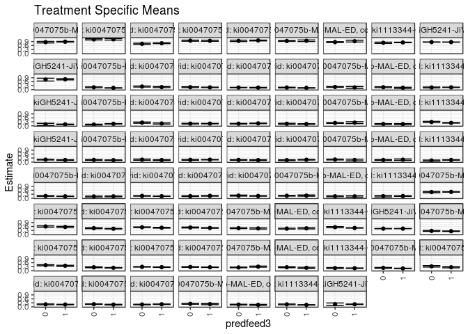

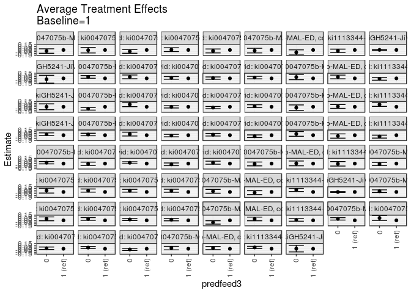

[figure not shown]

## Results Table

### Parameter: TSM

| agecat | studyid | country | intervention_level | baseline_level | estimate | ci_lower | ci_upper |
| --- | --- | --- | --- | --- | --- | --- | --- |
| 0-3 months | ki0047075b-MAL-ED | BANGLADESH | 1 | NA | 0.8839301 | 0.8579820 | 0.9098782 |
| 0-3 months | ki0047075b-MAL-ED | BANGLADESH | 0 | NA | 0.8532872 | 0.7948032 | 0.9117712 |
| 0-3 months | ki0047075b-MAL-ED | BRAZIL | 1 | NA | 1.0667214 | 1.0067610 | 1.1266818 |
| 0-3 months | ki0047075b-MAL-ED | BRAZIL | 0 | NA | 1.0593904 | 1.0125625 | 1.1062183 |
| 0-3 months | ki0047075b-MAL-ED | INDIA | 1 | NA | 0.7688412 | 0.7413906 | 0.7962919 |
| 0-3 months | ki0047075b-MAL-ED | INDIA | 0 | NA | 0.7277174 | 0.6819223 | 0.7735125 |
| 0-3 months | ki0047075b-MAL-ED | NEPAL | 1 | NA | 0.9539812 | 0.9149879 | 0.9929746 |
| 0-3 months | ki0047075b-MAL-ED | NEPAL | 0 | NA | 0.9628510 | 0.9241595 | 1.0015426 |
| 0-3 months | ki0047075b-MAL-ED | PERU | 1 | NA | 0.9765887 | 0.9479712 | 1.0052062 |
| 0-3 months | ki0047075b-MAL-ED | PERU | 0 | NA | 0.9491807 | 0.9001469 | 0.9982146 |
| 0-3 months | ki0047075b-MAL-ED | SOUTH AFRICA | 1 | NA | 0.9572647 | 0.8986504 | 1.0158790 |
| 0-3 months | ki0047075b-MAL-ED | SOUTH AFRICA | 0 | NA | 0.9394890 | 0.9076262 | 0.9713518 |
| 0-3 months | ki0047075b-MAL-ED | TANZANIA, UNITED REPUBLIC OF | 1 | NA | 0.9253052 | 0.8624631 | 0.9881472 |
| 0-3 months | ki0047075b-MAL-ED | TANZANIA, UNITED REPUBLIC OF | 0 | NA | 0.8553009 | 0.8176171 | 0.8929847 |
| 0-3 months | ki1113344-GMS-Nepal | NEPAL | 1 | NA | 0.8297987 | 0.8105273 | 0.8490702 |
| 0-3 months | ki1113344-GMS-Nepal | NEPAL | 0 | NA | 0.8050783 | 0.7590386 | 0.8511180 |
| 0-3 months | kiGH5241-JiVitA-3 | BANGLADESH | 1 | NA | 0.8567363 | 0.8529475 | 0.8605252 |
| 0-3 months | kiGH5241-JiVitA-3 | BANGLADESH | 0 | NA | 0.8587355 | 0.8483593 | 0.8691117 |
| 0-3 months | kiGH5241-JiVitA-4 | BANGLADESH | 1 | NA | 0.7809627 | 0.7357623 | 0.8261630 |
| 0-3 months | kiGH5241-JiVitA-4 | BANGLADESH | 0 | NA | 0.7561134 | 0.6506906 | 0.8615361 |
| 3-6 months | ki0047075b-MAL-ED | BANGLADESH | 1 | NA | 0.4774086 | 0.4587945 | 0.4960226 |
| 3-6 months | ki0047075b-MAL-ED | BANGLADESH | 0 | NA | 0.4644776 | 0.4208894 | 0.5080659 |
| 3-6 months | ki0047075b-MAL-ED | BRAZIL | 1 | NA | 0.5620749 | 0.5147037 | 0.6094461 |
| 3-6 months | ki0047075b-MAL-ED | BRAZIL | 0 | NA | 0.5998432 | 0.5499029 | 0.6497835 |
| 3-6 months | ki0047075b-MAL-ED | INDIA | 1 | NA | 0.4307602 | 0.4091107 | 0.4524097 |
| 3-6 months | ki0047075b-MAL-ED | INDIA | 0 | NA | 0.4713176 | 0.4315331 | 0.5111022 |
| 3-6 months | ki0047075b-MAL-ED | NEPAL | 1 | NA | 0.5047870 | 0.4741619 | 0.5354121 |
| 3-6 months | ki0047075b-MAL-ED | NEPAL | 0 | NA | 0.5399889 | 0.5132763 | 0.5667015 |
| 3-6 months | ki0047075b-MAL-ED | PERU | 1 | NA | 0.4860118 | 0.4624139 | 0.5096098 |
| 3-6 months | ki0047075b-MAL-ED | PERU | 0 | NA | 0.5212093 | 0.4857526 | 0.5566660 |

[output cut: 110 more lines]

### Parameter: E(Y)

| agecat | studyid | country | intervention_level | baseline_level | estimate | ci_lower | ci_upper |
| --- | --- | --- | --- | --- | --- | --- | --- |
| 0-3 months | ki0047075b-MAL-ED | BANGLADESH | NA | NA | 0.8782283 | 0.8546037 | 0.9018529 |
| 0-3 months | ki0047075b-MAL-ED | BRAZIL | NA | NA | 1.0646542 | 1.0280029 | 1.1013055 |
| 0-3 months | ki0047075b-MAL-ED | INDIA | NA | NA | 0.7574589 | 0.7340940 | 0.7808237 |
| 0-3 months | ki0047075b-MAL-ED | NEPAL | NA | NA | 0.9584228 | 0.9310012 | 0.9858444 |
| 0-3 months | ki0047075b-MAL-ED | PERU | NA | NA | 0.9695845 | 0.9443399 | 0.9948290 |
| 0-3 months | ki0047075b-MAL-ED | SOUTH AFRICA | NA | NA | 0.9436816 | 0.9164103 | 0.9709528 |
| 0-3 months | ki0047075b-MAL-ED | TANZANIA, UNITED REPUBLIC OF | NA | NA | 0.8823647 | 0.8498032 | 0.9149263 |
| 0-3 months | ki1113344-GMS-Nepal | NEPAL | NA | NA | 0.8249513 | 0.8069417 | 0.8429610 |
| 0-3 months | kiGH5241-JiVitA-3 | BANGLADESH | NA | NA | 0.8567788 | 0.8531299 | 0.8604277 |
| 0-3 months | kiGH5241-JiVitA-4 | BANGLADESH | NA | NA | 0.7701110 | 0.7280930 | 0.8121290 |
| 3-6 months | ki0047075b-MAL-ED | BANGLADESH | NA | NA | 0.4759067 | 0.4588572 | 0.4929562 |
| 3-6 months | ki0047075b-MAL-ED | BRAZIL | NA | NA | 0.5807629 | 0.5466123 | 0.6149135 |
| 3-6 months | ki0047075b-MAL-ED | INDIA | NA | NA | 0.4428354 | 0.4243688 | 0.4613020 |
| 3-6 months | ki0047075b-MAL-ED | NEPAL | NA | NA | 0.5212569 | 0.5007636 | 0.5417503 |
| 3-6 months | ki0047075b-MAL-ED | PERU | NA | NA | 0.4987110 | 0.4795495 | 0.5178726 |
| 3-6 months | ki0047075b-MAL-ED | SOUTH AFRICA | NA | NA | 0.4651960 | 0.4389728 | 0.4914192 |
| 3-6 months | ki0047075b-MAL-ED | TANZANIA, UNITED REPUBLIC OF | NA | NA | 0.4449049 | 0.4193050 | 0.4705047 |
| 3-6 months | ki1113344-GMS-Nepal | NEPAL | NA | NA | 0.4947387 | 0.4800952 | 0.5093821 |
| 3-6 months | kiGH5241-JiVitA-3 | BANGLADESH | NA | NA | 0.4392001 | 0.4352946 | 0.4431056 |
| 6-9 months | ki0047075b-MAL-ED | BANGLADESH | NA | NA | 0.2435771 | 0.2286416 | 0.2585125 |
| 6-9 months | ki0047075b-MAL-ED | BRAZIL | NA | NA | 0.3852363 | 0.3576221 | 0.4128505 |
| 6-9 months | ki0047075b-MAL-ED | INDIA | NA | NA | 0.2257708 | 0.2103479 | 0.2411937 |
| 6-9 months | ki0047075b-MAL-ED | NEPAL | NA | NA | 0.2707612 | 0.2558425 | 0.2856799 |
| 6-9 months | ki0047075b-MAL-ED | PERU | NA | NA | 0.2615943 | 0.2459743 | 0.2772143 |
| 6-9 months | ki0047075b-MAL-ED | SOUTH AFRICA | NA | NA | 0.2582981 | 0.2366643 | 0.2799319 |
| 6-9 months | ki0047075b-MAL-ED | TANZANIA, UNITED REPUBLIC OF | NA | NA | 0.2452641 | 0.2182544 | 0.2722738 |
| 6-9 months | ki1113344-GMS-Nepal | NEPAL | NA | NA | 0.1833726 | 0.1693467 | 0.1973984 |
| 9-12 months | ki0047075b-MAL-ED | BANGLADESH | NA | NA | 0.1742501 | 0.1603345 | 0.1881656 |
| 9-12 months | ki0047075b-MAL-ED | BRAZIL | NA | NA | 0.2870152 | 0.2525341 | 0.3214963 |
| 9-12 months | ki0047075b-MAL-ED | INDIA | NA | NA | 0.1750483 | 0.1600136 | 0.1900829 |
| 9-12 months | ki0047075b-MAL-ED | NEPAL | NA | NA | 0.1845885 | 0.1697713 | 0.1994057 |
| 9-12 months | ki0047075b-MAL-ED | PERU | NA | NA | 0.1859375 | 0.1706537 | 0.2012212 |
| 9-12 months | ki0047075b-MAL-ED | SOUTH AFRICA | NA | NA | 0.2134162 | 0.1908275 | 0.2360049 |
| 9-12 months | ki0047075b-MAL-ED | TANZANIA, UNITED REPUBLIC OF | NA | NA | 0.1579518 | 0.1360310 | 0.1798726 |
| 9-12 months | ki1113344-GMS-Nepal | NEPAL | NA | NA | 0.1493494 | 0.1349712 | 0.1637275 |
| 9-12 months | kiGH5241-JiVitA-4 | BANGLADESH | NA | NA | 0.1927867 | 0.1760286 | 0.2095447 |
| 12-15 months | ki0047075b-MAL-ED | BANGLADESH | NA | NA | 0.1349541 | 0.1188584 | 0.1510499 |
| 12-15 months | ki0047075b-MAL-ED | BRAZIL | NA | NA | 0.2098691 | 0.1830086 | 0.2367295 |
| 12-15 months | ki0047075b-MAL-ED | INDIA | NA | NA | 0.1746076 | 0.1576725 | 0.1915427 |
| 12-15 months | ki0047075b-MAL-ED | NEPAL | NA | NA | 0.1530291 | 0.1359519 | 0.1701063 |
| 12-15 months | ki0047075b-MAL-ED | PERU | NA | NA | 0.1429995 | 0.1263204 | 0.1596787 |
| 12-15 months | ki0047075b-MAL-ED | SOUTH AFRICA | NA | NA | 0.1888436 | 0.1630039 | 0.2146833 |
| 12-15 months | ki0047075b-MAL-ED | TANZANIA, UNITED REPUBLIC OF | NA | NA | 0.1670430 | 0.1409337 | 0.1931523 |
| 12-15 months | ki1113344-GMS-Nepal | NEPAL | NA | NA | 0.1715034 | 0.1574465 | 0.1855603 |
| 12-15 months | kiGH5241-JiVitA-4 | BANGLADESH | NA | NA | 0.1088810 | 0.0873587 | 0.1304034 |
| 15-18 months | ki0047075b-MAL-ED | BANGLADESH | NA | NA | 0.1419687 | 0.1260987 | 0.1578386 |
| 15-18 months | ki0047075b-MAL-ED | BRAZIL | NA | NA | 0.2081023 | 0.1789625 | 0.2372420 |
| 15-18 months | ki0047075b-MAL-ED | INDIA | NA | NA | 0.1670737 | 0.1513151 | 0.1828322 |
| 15-18 months | ki0047075b-MAL-ED | NEPAL | NA | NA | 0.1721904 | 0.1559804 | 0.1884004 |
| 15-18 months | ki0047075b-MAL-ED | PERU | NA | NA | 0.1444767 | 0.1256292 | 0.1633242 |
| 15-18 months | ki0047075b-MAL-ED | SOUTH AFRICA | NA | NA | 0.2221335 | 0.1931701 | 0.2510970 |
| 15-18 months | ki0047075b-MAL-ED | TANZANIA, UNITED REPUBLIC OF | NA | NA | 0.1366378 | 0.1119409 | 0.1613347 |
| 15-18 months | ki1113344-GMS-Nepal | NEPAL | NA | NA | 0.2313498 | 0.2143055 | 0.2483941 |
| 15-18 months | kiGH5241-JiVitA-4 | BANGLADESH | NA | NA | 0.1538108 | 0.1308637 | 0.1767579 |
| 18-21 months | ki0047075b-MAL-ED | BANGLADESH | NA | NA | 0.1441563 | 0.1270864 | 0.1612262 |
| 18-21 months | ki0047075b-MAL-ED | BRAZIL | NA | NA | 0.1618510 | 0.1358468 | 0.1878551 |
| 18-21 months | ki0047075b-MAL-ED | INDIA | NA | NA | 0.1719770 | 0.1564970 | 0.1874571 |
| 18-21 months | ki0047075b-MAL-ED | NEPAL | NA | NA | 0.1511761 | 0.1334727 | 0.1688794 |
| 18-21 months | ki0047075b-MAL-ED | PERU | NA | NA | 0.1620790 | 0.1430444 | 0.1811137 |
| 18-21 months | ki0047075b-MAL-ED | SOUTH AFRICA | NA | NA | 0.1798838 | 0.1527878 | 0.2069798 |
| 18-21 months | ki0047075b-MAL-ED | TANZANIA, UNITED REPUBLIC OF | NA | NA | 0.1578080 | 0.1309046 | 0.1847113 |
| 18-21 months | ki1113344-GMS-Nepal | NEPAL | NA | NA | 0.1478606 | 0.1308537 | 0.1648675 |
| 21-24 months | ki0047075b-MAL-ED | BANGLADESH | NA | NA | 0.1485991 | 0.1337648 | 0.1634334 |
| 21-24 months | ki0047075b-MAL-ED | BRAZIL | NA | NA | 0.1369019 | 0.1132291 | 0.1605747 |
| 21-24 months | ki0047075b-MAL-ED | INDIA | NA | NA | 0.1590319 | 0.1452622 | 0.1728016 |
| 21-24 months | ki0047075b-MAL-ED | NEPAL | NA | NA | 0.1662354 | 0.1463078 | 0.1861631 |
| 21-24 months | ki0047075b-MAL-ED | PERU | NA | NA | 0.1814454 | 0.1615858 | 0.2013051 |
| 21-24 months | ki0047075b-MAL-ED | SOUTH AFRICA | NA | NA | 0.1880230 | 0.1639514 | 0.2120945 |
| 21-24 months | ki0047075b-MAL-ED | TANZANIA, UNITED REPUBLIC OF | NA | NA | 0.1380758 | 0.1082723 | 0.1678793 |
| 21-24 months | ki1113344-GMS-Nepal | NEPAL | NA | NA | 0.1608641 | 0.1363372 | 0.1853911 |

### Parameter: ATE

| agecat | studyid | country | intervention_level | baseline_level | estimate | ci_lower | ci_upper |
| --- | --- | --- | --- | --- | --- | --- | --- |
| 0-3 months | ki0047075b-MAL-ED | BANGLADESH | 1 | 1 | 0.0000000 | 0.0000000 | 0.0000000 |
| 0-3 months | ki0047075b-MAL-ED | BANGLADESH | 0 | 1 | -0.0306429 | -0.0946828 | 0.0333970 |
| 0-3 months | ki0047075b-MAL-ED | BRAZIL | 1 | 1 | 0.0000000 | 0.0000000 | 0.0000000 |
| 0-3 months | ki0047075b-MAL-ED | BRAZIL | 0 | 1 | -0.0073310 | -0.0856956 | 0.0710336 |
| 0-3 months | ki0047075b-MAL-ED | INDIA | 1 | 1 | 0.0000000 | 0.0000000 | 0.0000000 |
| 0-3 months | ki0047075b-MAL-ED | INDIA | 0 | 1 | -0.0411238 | -0.0946080 | 0.0123604 |
| 0-3 months | ki0047075b-MAL-ED | NEPAL | 1 | 1 | 0.0000000 | 0.0000000 | 0.0000000 |
| 0-3 months | ki0047075b-MAL-ED | NEPAL | 0 | 1 | 0.0088698 | -0.0460751 | 0.0638146 |
| 0-3 months | ki0047075b-MAL-ED | PERU | 1 | 1 | 0.0000000 | 0.0000000 | 0.0000000 |
| 0-3 months | ki0047075b-MAL-ED | PERU | 0 | 1 | -0.0274080 | -0.0840854 | 0.0292695 |
| 0-3 months | ki0047075b-MAL-ED | SOUTH AFRICA | 1 | 1 | 0.0000000 | 0.0000000 | 0.0000000 |
| 0-3 months | ki0047075b-MAL-ED | SOUTH AFRICA | 0 | 1 | -0.0177757 | -0.0844691 | 0.0489176 |
| 0-3 months | ki0047075b-MAL-ED | TANZANIA, UNITED REPUBLIC OF | 1 | 1 | 0.0000000 | 0.0000000 | 0.0000000 |
| 0-3 months | ki0047075b-MAL-ED | TANZANIA, UNITED REPUBLIC OF | 0 | 1 | -0.0700043 | -0.1435431 | 0.0035346 |
| 0-3 months | ki1113344-GMS-Nepal | NEPAL | 1 | 1 | 0.0000000 | 0.0000000 | 0.0000000 |
| 0-3 months | ki1113344-GMS-Nepal | NEPAL | 0 | 1 | -0.0247204 | -0.0742696 | 0.0248288 |
| 0-3 months | kiGH5241-JiVitA-3 | BANGLADESH | 1 | 1 | 0.0000000 | 0.0000000 | 0.0000000 |
| 0-3 months | kiGH5241-JiVitA-3 | BANGLADESH | 0 | 1 | 0.0019992 | -0.0087159 | 0.0127143 |
| 0-3 months | kiGH5241-JiVitA-4 | BANGLADESH | 1 | 1 | 0.0000000 | 0.0000000 | 0.0000000 |
| 0-3 months | kiGH5241-JiVitA-4 | BANGLADESH | 0 | 1 | -0.0248493 | -0.1386595 | 0.0889608 |
| 3-6 months | ki0047075b-MAL-ED | BANGLADESH | 1 | 1 | 0.0000000 | 0.0000000 | 0.0000000 |
| 3-6 months | ki0047075b-MAL-ED | BANGLADESH | 0 | 1 | -0.0129309 | -0.0603147 | 0.0344528 |
| 3-6 months | ki0047075b-MAL-ED | BRAZIL | 1 | 1 | 0.0000000 | 0.0000000 | 0.0000000 |
| 3-6 months | ki0047075b-MAL-ED | BRAZIL | 0 | 1 | 0.0377683 | -0.0316034 | 0.1071400 |
| 3-6 months | ki0047075b-MAL-ED | INDIA | 1 | 1 | 0.0000000 | 0.0000000 | 0.0000000 |
| 3-6 months | ki0047075b-MAL-ED | INDIA | 0 | 1 | 0.0405574 | -0.0049312 | 0.0860460 |
| 3-6 months | ki0047075b-MAL-ED | NEPAL | 1 | 1 | 0.0000000 | 0.0000000 | 0.0000000 |
| 3-6 months | ki0047075b-MAL-ED | NEPAL | 0 | 1 | 0.0352019 | -0.0054302 | 0.0758340 |
| 3-6 months | ki0047075b-MAL-ED | PERU | 1 | 1 | 0.0000000 | 0.0000000 | 0.0000000 |
| 3-6 months | ki0047075b-MAL-ED | PERU | 0 | 1 | 0.0351974 | -0.0083633 | 0.0787582 |

[output cut: 110 more lines]

### Parameter: PAR

| agecat | studyid | country | intervention_level | baseline_level | estimate | ci_lower | ci_upper |
| --- | --- | --- | --- | --- | --- | --- | --- |
| 0-3 months | ki0047075b-MAL-ED | BANGLADESH | 1 | NA | -0.0057018 | -0.0173634 | 0.0059599 |
| 0-3 months | ki0047075b-MAL-ED | BRAZIL | 1 | NA | -0.0020672 | -0.0427677 | 0.0386333 |
| 0-3 months | ki0047075b-MAL-ED | INDIA | 1 | NA | -0.0113824 | -0.0264895 | 0.0037247 |
| 0-3 months | ki0047075b-MAL-ED | NEPAL | 1 | NA | 0.0044416 | -0.0235980 | 0.0324812 |
| 0-3 months | ki0047075b-MAL-ED | PERU | 1 | NA | -0.0070042 | -0.0268849 | 0.0128765 |
| 0-3 months | ki0047075b-MAL-ED | SOUTH AFRICA | 1 | NA | -0.0135831 | -0.0648460 | 0.0376797 |
| 0-3 months | ki0047075b-MAL-ED | TANZANIA, UNITED REPUBLIC OF | 1 | NA | -0.0429404 | -0.0961704 | 0.0102895 |
| 0-3 months | ki1113344-GMS-Nepal | NEPAL | 1 | NA | -0.0048474 | -0.0133438 | 0.0036490 |
| 0-3 months | kiGH5241-JiVitA-3 | BANGLADESH | 1 | NA | 0.0000425 | -0.0009922 | 0.0010771 |
| 0-3 months | kiGH5241-JiVitA-4 | BANGLADESH | 1 | NA | -0.0108517 | -0.0224664 | 0.0007631 |
| 3-6 months | ki0047075b-MAL-ED | BANGLADESH | 1 | NA | -0.0015019 | -0.0101138 | 0.0071101 |
| 3-6 months | ki0047075b-MAL-ED | BRAZIL | 1 | NA | 0.0186880 | -0.0162214 | 0.0535974 |
| 3-6 months | ki0047075b-MAL-ED | INDIA | 1 | NA | 0.0120751 | -0.0006187 | 0.0247690 |
| 3-6 months | ki0047075b-MAL-ED | NEPAL | 1 | NA | 0.0164699 | -0.0041931 | 0.0371329 |
| 3-6 months | ki0047075b-MAL-ED | PERU | 1 | NA | 0.0126992 | -0.0022004 | 0.0275988 |
| 3-6 months | ki0047075b-MAL-ED | SOUTH AFRICA | 1 | NA | 0.0142908 | -0.0273240 | 0.0559057 |
| 3-6 months | ki0047075b-MAL-ED | TANZANIA, UNITED REPUBLIC OF | 1 | NA | -0.0148482 | -0.0550164 | 0.0253199 |
| 3-6 months | ki1113344-GMS-Nepal | NEPAL | 1 | NA | 0.0075737 | -0.0000468 | 0.0151943 |
| 3-6 months | kiGH5241-JiVitA-3 | BANGLADESH | 1 | NA | -0.0001177 | -0.0011985 | 0.0009630 |
| 6-9 months | ki0047075b-MAL-ED | BANGLADESH | 1 | NA | 0.0002705 | -0.0070226 | 0.0075636 |
| 6-9 months | ki0047075b-MAL-ED | BRAZIL | 1 | NA | 0.0205346 | -0.0067469 | 0.0478161 |
| 6-9 months | ki0047075b-MAL-ED | INDIA | 1 | NA | 0.0129449 | 0.0013421 | 0.0245478 |
| 6-9 months | ki0047075b-MAL-ED | NEPAL | 1 | NA | 0.0103882 | -0.0050693 | 0.0258457 |
| 6-9 months | ki0047075b-MAL-ED | PERU | 1 | NA | 0.0068577 | -0.0044435 | 0.0181590 |
| 6-9 months | ki0047075b-MAL-ED | SOUTH AFRICA | 1 | NA | -0.0428064 | -0.0792637 | -0.0063492 |
| 6-9 months | ki0047075b-MAL-ED | TANZANIA, UNITED REPUBLIC OF | 1 | NA | 0.0315875 | -0.0058177 | 0.0689927 |
| 6-9 months | ki1113344-GMS-Nepal | NEPAL | 1 | NA | 0.0012789 | -0.0047204 | 0.0072781 |
| 9-12 months | ki0047075b-MAL-ED | BANGLADESH | 1 | NA | 0.0076621 | 0.0012476 | 0.0140766 |
| 9-12 months | ki0047075b-MAL-ED | BRAZIL | 1 | NA | 0.0322677 | -0.0023783 | 0.0669136 |
| 9-12 months | ki0047075b-MAL-ED | INDIA | 1 | NA | 0.0043620 | -0.0065362 | 0.0152602 |
| 9-12 months | ki0047075b-MAL-ED | NEPAL | 1 | NA | 0.0201242 | 0.0038591 | 0.0363893 |
| 9-12 months | ki0047075b-MAL-ED | PERU | 1 | NA | -0.0062311 | -0.0164041 | 0.0039419 |
| 9-12 months | ki0047075b-MAL-ED | SOUTH AFRICA | 1 | NA | 0.0091674 | -0.0283116 | 0.0466463 |
| 9-12 months | ki0047075b-MAL-ED | TANZANIA, UNITED REPUBLIC OF | 1 | NA | 0.0114835 | -0.0210390 | 0.0440059 |
| 9-12 months | ki1113344-GMS-Nepal | NEPAL | 1 | NA | 0.0048953 | -0.0003467 | 0.0101374 |
| 9-12 months | kiGH5241-JiVitA-4 | BANGLADESH | 1 | NA | 0.0020313 | -0.0062418 | 0.0103044 |
| 12-15 months | ki0047075b-MAL-ED | BANGLADESH | 1 | NA | 0.0057924 | -0.0014546 | 0.0130394 |
| 12-15 months | ki0047075b-MAL-ED | BRAZIL | 1 | NA | 0.0191220 | -0.0066982 | 0.0449422 |
| 12-15 months | ki0047075b-MAL-ED | INDIA | 1 | NA | 0.0045302 | -0.0070667 | 0.0161271 |
| 12-15 months | ki0047075b-MAL-ED | NEPAL | 1 | NA | 0.0035797 | -0.0133780 | 0.0205374 |
| 12-15 months | ki0047075b-MAL-ED | PERU | 1 | NA | 0.0119570 | -0.0004305 | 0.0243445 |
| 12-15 months | ki0047075b-MAL-ED | SOUTH AFRICA | 1 | NA | 0.0241638 | -0.0317760 | 0.0801036 |
| 12-15 months | ki0047075b-MAL-ED | TANZANIA, UNITED REPUBLIC OF | 1 | NA | 0.0290860 | -0.0090861 | 0.0672581 |
| 12-15 months | ki1113344-GMS-Nepal | NEPAL | 1 | NA | -0.0024342 | -0.0082702 | 0.0034018 |
| 12-15 months | kiGH5241-JiVitA-4 | BANGLADESH | 1 | NA | -0.0000186 | -0.0059997 | 0.0059624 |
| 15-18 months | ki0047075b-MAL-ED | BANGLADESH | 1 | NA | -0.0091801 | -0.0163589 | -0.0020013 |
| 15-18 months | ki0047075b-MAL-ED | BRAZIL | 1 | NA | 0.0326668 | 0.0019302 | 0.0634035 |
| 15-18 months | ki0047075b-MAL-ED | INDIA | 1 | NA | 0.0005521 | -0.0096687 | 0.0107729 |
| 15-18 months | ki0047075b-MAL-ED | NEPAL | 1 | NA | -0.0124367 | -0.0287749 | 0.0039016 |
| 15-18 months | ki0047075b-MAL-ED | PERU | 1 | NA | 0.0056543 | -0.0077834 | 0.0190919 |
| 15-18 months | ki0047075b-MAL-ED | SOUTH AFRICA | 1 | NA | -0.0188087 | -0.0795508 | 0.0419335 |
| 15-18 months | ki0047075b-MAL-ED | TANZANIA, UNITED REPUBLIC OF | 1 | NA | 0.0101359 | -0.0285965 | 0.0488683 |
| 15-18 months | ki1113344-GMS-Nepal | NEPAL | 1 | NA | 0.0098237 | 0.0007916 | 0.0188558 |
| 15-18 months | kiGH5241-JiVitA-4 | BANGLADESH | 1 | NA | 0.0030415 | -0.0014295 | 0.0075124 |
| 18-21 months | ki0047075b-MAL-ED | BANGLADESH | 1 | NA | 0.0042577 | -0.0028403 | 0.0113558 |
| 18-21 months | ki0047075b-MAL-ED | BRAZIL | 1 | NA | 0.0135928 | -0.0127366 | 0.0399222 |
| 18-21 months | ki0047075b-MAL-ED | INDIA | 1 | NA | -0.0038501 | -0.0148484 | 0.0071482 |
| 18-21 months | ki0047075b-MAL-ED | NEPAL | 1 | NA | 0.0066492 | -0.0122083 | 0.0255068 |
| 18-21 months | ki0047075b-MAL-ED | PERU | 1 | NA | -0.0102992 | -0.0233086 | 0.0027102 |
| 18-21 months | ki0047075b-MAL-ED | SOUTH AFRICA | 1 | NA | 0.0277393 | -0.0263187 | 0.0817973 |
| 18-21 months | ki0047075b-MAL-ED | TANZANIA, UNITED REPUBLIC OF | 1 | NA | -0.0209017 | -0.0644618 | 0.0226583 |
| 18-21 months | ki1113344-GMS-Nepal | NEPAL | 1 | NA | -0.0072949 | -0.0140386 | -0.0005512 |
| 21-24 months | ki0047075b-MAL-ED | BANGLADESH | 1 | NA | 0.0046242 | -0.0016050 | 0.0108533 |
| 21-24 months | ki0047075b-MAL-ED | BRAZIL | 1 | NA | -0.0030731 | -0.0258031 | 0.0196568 |
| 21-24 months | ki0047075b-MAL-ED | INDIA | 1 | NA | 0.0070178 | -0.0021594 | 0.0161949 |
| 21-24 months | ki0047075b-MAL-ED | NEPAL | 1 | NA | -0.0136976 | -0.0339631 | 0.0065679 |
| 21-24 months | ki0047075b-MAL-ED | PERU | 1 | NA | 0.0085377 | -0.0058189 | 0.0228944 |
| 21-24 months | ki0047075b-MAL-ED | SOUTH AFRICA | 1 | NA | -0.0084404 | -0.0495824 | 0.0327016 |
| 21-24 months | ki0047075b-MAL-ED | TANZANIA, UNITED REPUBLIC OF | 1 | NA | -0.0021244 | -0.0508606 | 0.0466118 |
| 21-24 months | ki1113344-GMS-Nepal | NEPAL | 1 | NA | -0.0019990 | -0.0116679 | 0.0076699 |